# DTSC 650: Data Analytics In R

CodeGrade Final Project Part 2

## Student Info

```
Name: Rhonda Gray
Term: Fall 1
Date:10/13/2024
```

## General Instructions

### Academic Integrity

We expect all work conducted at Eastern University to reflect honest and ethical behavior. The primary rule for ensuring academic integrity is that all submitted work must be original and produced by the individual student.

To uphold academic integrity, it is not permitted to view another student’s work prior to submitting your own, nor should you provide your work to someone who has not yet submitted their work. Collaborating with other students is only allowed when seeking clarification on a topic or assignment instructions.

See the syllabus for more information.

### Name of File

Name your assignment file **`Final_Project_Part2.qmd`**. This is a quarto “markdown” file, which has the extension “.qmd”.

### Instructions

For the final section, you will choose four variables to explore. These four variables must be *different* than the three analyzed in Q1-10. Select one of the four variables you chose as the response variable and the other three as predictors. Be sure to read through all of the instructions for Q11-Q15 before choosing your 4 variables.

Feel free to create multiple variables for Q12, Q13, and Q14, e.g. Q12a, Q12b, etc. Please make it clear, though, the distinction between each question/problem with comments, spacing, and new code chunks. If you use Q12a, b, etc., be sure to print the results by doing Q12a or print(Q12a). It is allowable to use `print()` on this part. Your answers must be clearly identifiable.

Take time to tidy your code once you are finished. The easier it is for us to understand, the more credit you could receive.

### Allowable packages

The only allowable packages are `tidyverse`, `caret`, `Hmisc`, `lsr`, `olsrr`, `psych`, `lm.beta`.

- If the allowable packages are not installed on your local computer, you’ll need to do a one-time installation *from the Console Window in RStudio* for each package like this:

  **`install.packages('<package name>')`**

  *Do not attempt to install packages in code that you submit to CodeGrade.*
- Note: installing the entire tidyverse with `install.packages('tidyverse')` from the Console Window will save you from having to install any of the tidyverse’s individual packages in the future.
- In your code, load the package’s library like this: **`library(<library name>)`**

### Do / Do not

- Do use tidyverse functions (e.g., dplyr verbs) for all of the questions where possible.
- Do use The Pipe, either `%>%` or `|>`.
- Do use plenty of comments throughout your code chunks so that the grader can follow your line of thinking.
- Do use the “Q Discussion:” sections provided to explain your thinking and to answer the questions.
- Do not rearrange data frame outputs unless specified by the question instructions.
- Do not create multiple copies of the BRFSS dataset in your script.
- Do have integrity and submit your own work, not the work of a classmate, an online resource, or someone else.
- Do not edit the CSV file in Excel, Numbers, Sheets, etc.

### Submission

You only have ONE ATTEMPT to submit Part 2 to the ACTUAL submission link! On all the other assignments, you got multiple attempts; but not on this assignment.

Ensure you are ready and confident in your work before submitting.

### Data Set

- These data come from the Centers for Disease Control
- To answer these questions you will need to use the codebook on Brightspace, called `BRFSS_2021 Codebook`. For part 2 of the project, please note that not all of the variables listed in the codebook are included in the .csv file to be downloaded from Brightspace.
- Download the `brfss2021.csv` file from Brightspace and place it in the same folder/directory as your script file. Then in RStudio, set your Working Directory to your Source File location: in the menus choose Session | Set Working Directory | To Source File Location. You most likely will see some warnings after it loads due to the fact that `read_csv()` will try to guess the column type but because there are so many rows it won’t read enough of them to accurately make a guess.
- You must use the `read_csv()` function when loading the .csv file. Do not use read.csv().
- Do not rename the .csv file that you download from Brightspace.
- Do not edit the .csv file.

### Pipe Notation

You may use the `tidyverse` pipe **`%>%`** or the new base R pipe **`|>`**. For a comparison, see [here](https://www.tidyverse.org/blog/2023/04/base-vs-magrittr-pipe/).

You are expected to use pipe notation in all of the CodeGrade assignments. Although there are alternate ways to filter, subset, and summarize data sets, using the pipe creates more readable code and is an important skill to develop.

### Comments vs. Discussion

You should include both comments within your code chunk as well a discussion after each coded answer. Comments explain your code and your thought process; the discussion uses your code to answer the questions we’ve asked. We have provided “Q Discussion” sections for each question. Feel free to add more lines in the discussion section.

You can also use markdown headers to organize your discussion and the outline. For more info on markdown, see [here](https://rmarkdown.rstudio.com/authoring_basics.html)

### Rounding requirement

Unlike Part 1, there is no rounding requirement. Use your best judgment.

### Dataframe vs. Tibble

Unlike Part 1, there is no dataframe requirement.

## Questions and Coded Solutions

## Questions

### Q11

Address the values of each of the variables (use the codebook for this and include your answer as comments). For instance, is “none” equal to a value other than 0? Are there extra decimals implied? Are there other values that should be excluded based on the responses they represent? Which variable will you seek to predict from the other variables? Answer these questions in the *Q11 Discussion:* section below the code chunk. Update the dataset to account for these values for the remainder of the questions.

```r
### Do not edit the following line. It is used by CodeGrade.
# CG Q11 #

### TYPE YOUR CODE BELOW ###


brf_part2 <- brf |>
  select(MAXDRNKS, ALCDAY5, BIRTHSEX, INCOME3) |>
as.data.frame()


brf_part2 <- brf_part2 %>%
  filter(
    !BIRTHSEX %in% c(7, 9) &  # Remove unwanted responses
    !INCOME3 %in% c(77, 99) &  # Remove unwanted responses
    !ALCDAY5 %in% c(777,999,888) &
    !MAXDRNKS %in% c(77,99)

  ) %>%
 filter(!is.na(MAXDRNKS) & !is.na(BIRTHSEX) & !is.na(INCOME3))



#Create variable DKDAY to show number of times they drink per week

brf_part2 <- brf_part2 %>%
  mutate(
    DKDAY = case_when(
      ALCDAY5 > 0 & ALCDAY5 < 200 ~ round(as.numeric(substr(as.character(ALCDAY5), 2, nchar(as.character(ALCDAY5)))), 2),
      ALCDAY5 >= 200 & ALCDAY5 < 300 ~ round(as.numeric(substr(as.character(ALCDAY5), 2, nchar(as.character(ALCDAY5)))) / 7, 2),
      TRUE ~ ALCDAY5 # Handle other cases
    )
  ) |>

  select(DKDAY, everything(), -ALCDAY5)  # Place DKDAY as the first column and remove ALCDAY5

Q11 <- slice_head(brf_part2, n = 10)

Q11 #show first 10 rows of new data
```

| DKDAY | MAXDRNKS | BIRTHSEX | INCOME3 |
| --- | --- | --- | --- |
| 0.29 | 1 | 2 | 5 |
| 0.43 | 1 | 2 | 11 |
| 2.14 | 1 | 2 | 6 |
| 1.00 | 3 | 2 | 9 |
| 4.29 | 12 | 1 | 6 |
| 2.00 | 3 | 1 | 7 |
| 0.14 | 1 | 1 | 4 |
| 4.29 | 5 | 1 | 8 |
| 3.00 | 1 | 2 | 6 |
| 0.57 | 1 | 1 | 10 |

```r
#glimpse(brf_part2)


# unique(brf_part2$DKDAY)
```

### Q11 Discussion:

Your Q11 discussion goes here. Feel free to add more lines as needed.

This project will explore and analyse the effect of income, birth sex on alcohol consumption levels. It will also look at how max number of drinks on one occasion for an individual effect the weekly alcohol consumption levels. Those who responded “don’t know/not sure” or “refused” will be excluded during Q11 step of to streamline the output for analysis. NA’s from “MAXDRNKS” and “BIRTHSEX” are removed to clean excessive NA values. I wanted to use the “ORACE3” as a variable to look at Race but it was not listed in the actual brf dataset so I chose to add “ALCDAY5 to strengthen understanding of drinking patterns. I created a new variable called”DKDAY” using “ALCDAY5” to show the number of times they drank per week. This is a measurable number to be used to compare variable relationships. The 4 variables I will use include “MAXDRNKS”,“BIRTHSEX” “INCOME3”,and “DKDAY”.

“MAXDRNKS” indicates the max number of drinks someone had on any occasion in the last 30 days. The coding and levels for “MAXDRNKS”:

Number of drinks 77 Don’t know / Not sure 99 Refused

The coding and levels for “ALCDAY5” (converted into “DKDAY” *values included below)

1 _ _ Days per week 2 _ _ Days in past 30 days Read if necessary: A 40-ounce beer would count as 3 drinks, or a cocktail drink with 2 shots would count as 2 drinks. 888 No drinks in past 30 days 777 Don’t know / Not sure 999 refused

“DKDAY” shows number of times they drink per week. Value range is 0.14 - 7. This variable is trimmed to only show range 1-7.

“BIRTHSEX” is binary and indicates sex of male or female at the time of birth. The coding and levels for “BIRTHSEX”:

1 Male 2 Female 7 Don’t know/Not sure 9 Refused

“INCOME3” notes the annual household income from all sources. The coding and levels for “Income3”:

01 Less than $10,000? 02 Less than $15,000? ($10,000 to less than $15,000) 03 Less than $20,000? ($15,000 to less than $20,000) 04 Less than $25,000 05 Less than $35,000 If ($25,000 to less than $35,000) 06 Less than $50,000 If ($35,000 to less than $50,000) 07 Less than $75,000? ($50,000 to less than $75,000) 08 Less than $100,000? ($75,000 to less than $100,000) 09 Less than $150,000? ($100,000 to less than $150,000)? 10 Less than $200,000? ($150,000 to less than $200,000) 11 $200,000 or more 77 Don’t know / Not sure 99 Refused

### Q12

Remove any outliers for each applicable variable. Make sure you are updating the dataset from Q11 and using this dataset for the remainder of the questions. Briefly explain why you chose the method you used in the *Q12 Discussion* section. Within your code chunk, provide comments explaining what your code is doing.

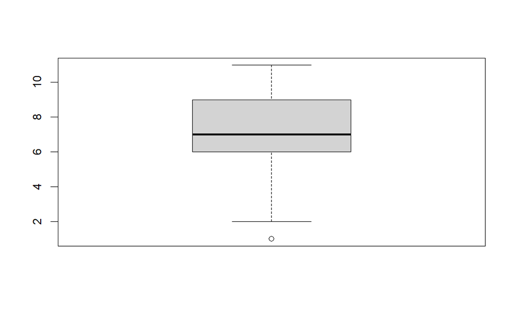

```r
### Do not edit the following line. It is used by CodeGrade.
# CG Q12 #

### TYPE YOUR CODE BELOW ###

#boxplot(brf_part2$DKDAY)

#unique(brf_partt$DKDAY)

#Create boxplot of MAXDRNKS

#boxplot(brf_part2$MAXDRNKS)

#create boxplot for INCOME3
boxplot(brf_part2$INCOME3)
```

```r
brf_part2 <- brf_part2 %>% #remove outliers for under 1
  filter(DKDAY >= 1)

#create upper fence for Income using IQR quantile
upper_fence <- quantile(brf_part2$INCOME3, 0.75) + (1.5 * IQR(brf_part2$INCOME3))

#remove outliers from income
brf_part2 <- brf_part2 |>
  filter (
    INCOME3 < upper_fence
  )
#create upper fence for MAXDRINKS using IQR quantile
upper_fence2 <- quantile(brf_part2$MAXDRNKS, 0.75) + (1.5 * IQR(brf_part2$MAXDRNKS))

#remove outliers from MAXDRNKS
brf_part2 <- brf_part2 |>
  filter (
    MAXDRNKS < upper_fence
  )
```

### Q13

Complete exploratory analyses (for each variable) doing appropriate visualizations with ggplot2. Include visualizations that incorporate a combination of your variables within one plot. Provide an organized discussion of your observations for each of the plots in the *Q13 Discussion* section below.

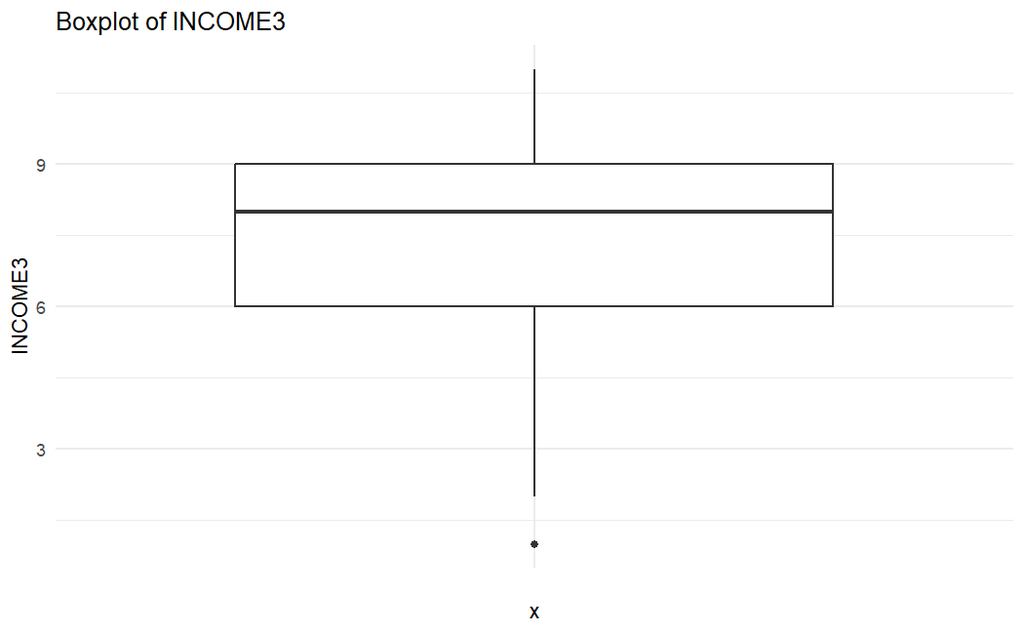

```r
### Do not edit the following line. It is used by CodeGrade.
# CG Q13 #

### TYPE YOUR CODE BELOW ###

#INCOME3
ggplot(brf_part2, aes(x = "", y = INCOME3)) +
  geom_boxplot() +
  labs(title = "Boxplot of INCOME3", y = "INCOME3") +
  theme_minimal()
```

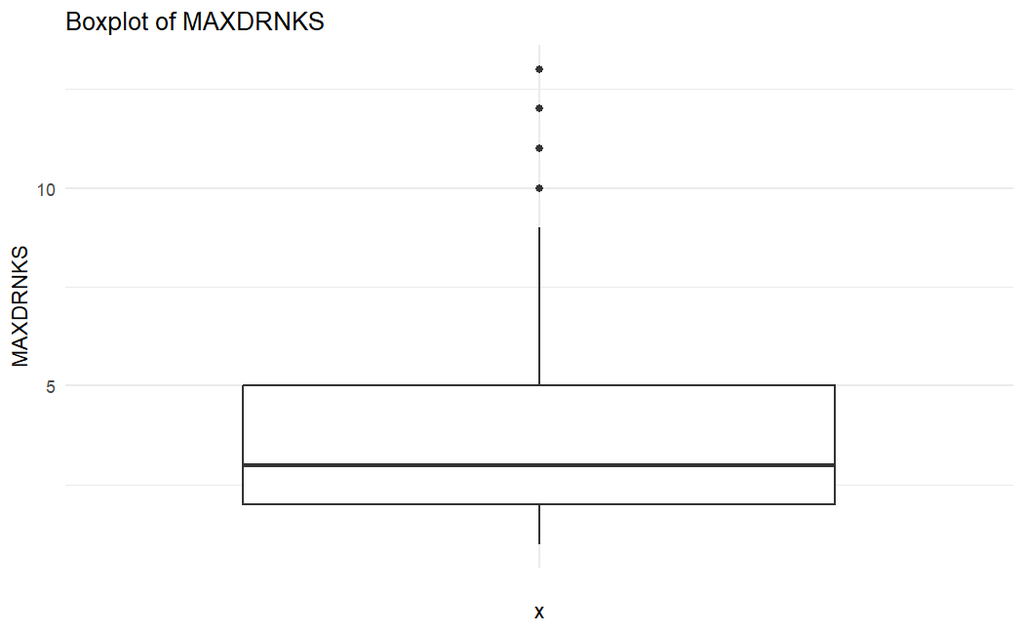

```r
#MaXdRNKs
ggplot(brf_part2, aes(x = "", y = MAXDRNKS)) +
  geom_boxplot() +
  labs(title = "Boxplot of MAXDRNKS", y = "MAXDRNKS") +
  theme_minimal()
```

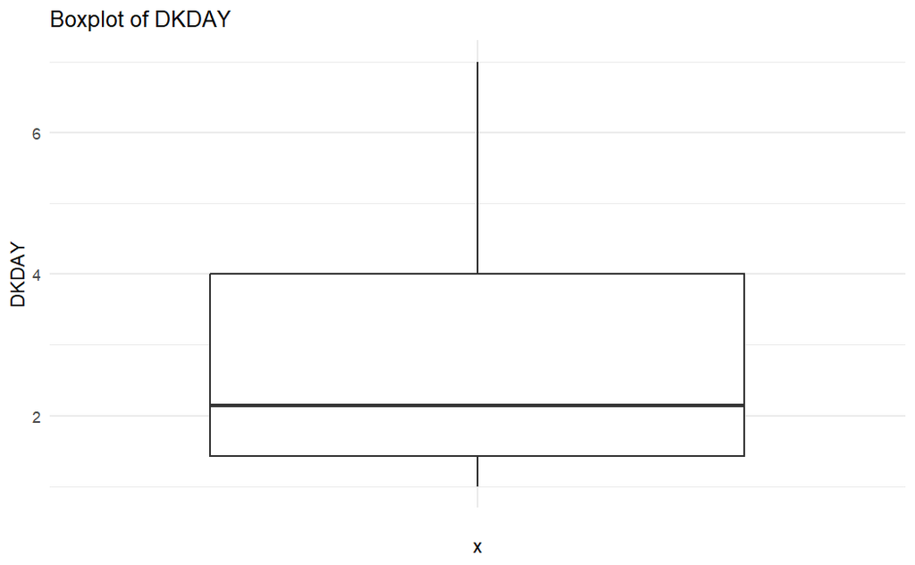

```r
#DKDAY
ggplot(brf_part2, aes(x = "", y = DKDAY)) +
  geom_boxplot() +
  labs(title = "Boxplot of DKDAY", y = "DKDAY") +
  theme_minimal()
```